# Modelling temporal trends

Alain Danet

10 février, 2022

```r
library(INLA)
library(inlatools)
library(inlabru)
library(spaMM)
library("glmmTMB")
library(DHARMa)
library(ggeffects)
library(emmeans)
```

# Model ALL in ONE

## spaMM

### Jaccard

- Quite a lot of 0 and 1, it can be problematic for beta regression

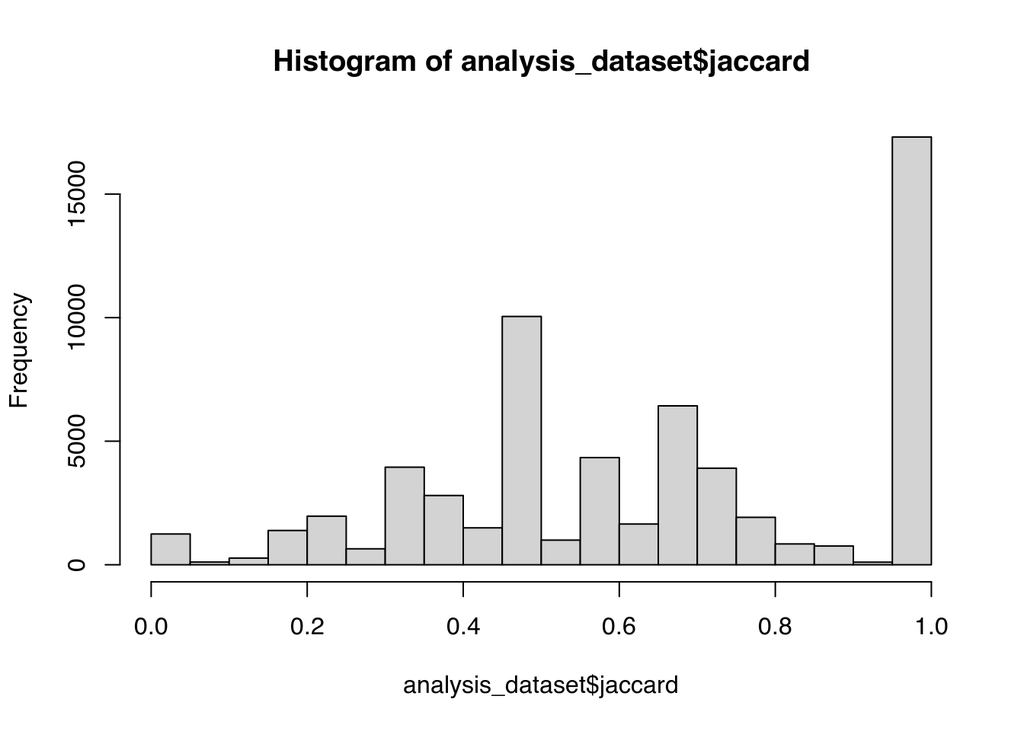

```r
hist(analysis_dataset$jaccard)
```

```r
summary(analysis_dataset$jaccard)
```

```
#>    Min. 1st Qu.  Median    Mean 3rd Qu.    Max.
#>  0.0000  0.5000  0.6667  0.6535  1.0000  1.0000
```

```r
x <- rbinom(20, 1, .5)
transform01(x)
```

```
#>  [1] 0.975 0.975 0.975 0.025 0.975 0.975 0.975 0.025 0.975 0.975 0.025 0.975 0.975 0.025 0.975 0.025 0.025 0.975 0.975 0.975
```

```r
analysis_dataset$jaccard_scaled <- transform01(analysis_dataset$jaccard)
analysis_dataset$main_bas <- as.character(analysis_dataset$main_bas)
```

- Better to transform variable on the na.omit data

```r
summary(analysis_dataset$jaccard_scaled)
```

```
#>     Min.  1st Qu.   Median     Mean  3rd Qu.     Max.
#> 0.000008 0.500000 0.666664 0.653488 0.999992 0.999992
```

```r
ti <- analysis_dataset %>%
  na.omit() %>%
  mutate(jaccard_scaled = transform01(jaccard))
summary(ti[, c("jaccard", "jaccard_scaled")])
```

```
#>     jaccard       jaccard_scaled
#>  Min.   :0.0000   Min.   :0.0000332
#>  1st Qu.:0.5000   1st Qu.:0.5000000
#>  Median :0.6667   Median :0.6666556
#>  Mean   :0.6607   Mean   :0.6606986
#>  3rd Qu.:0.8571   3rd Qu.:0.8571192
#>  Max.   :1.0000   Max.   :0.9999668
```

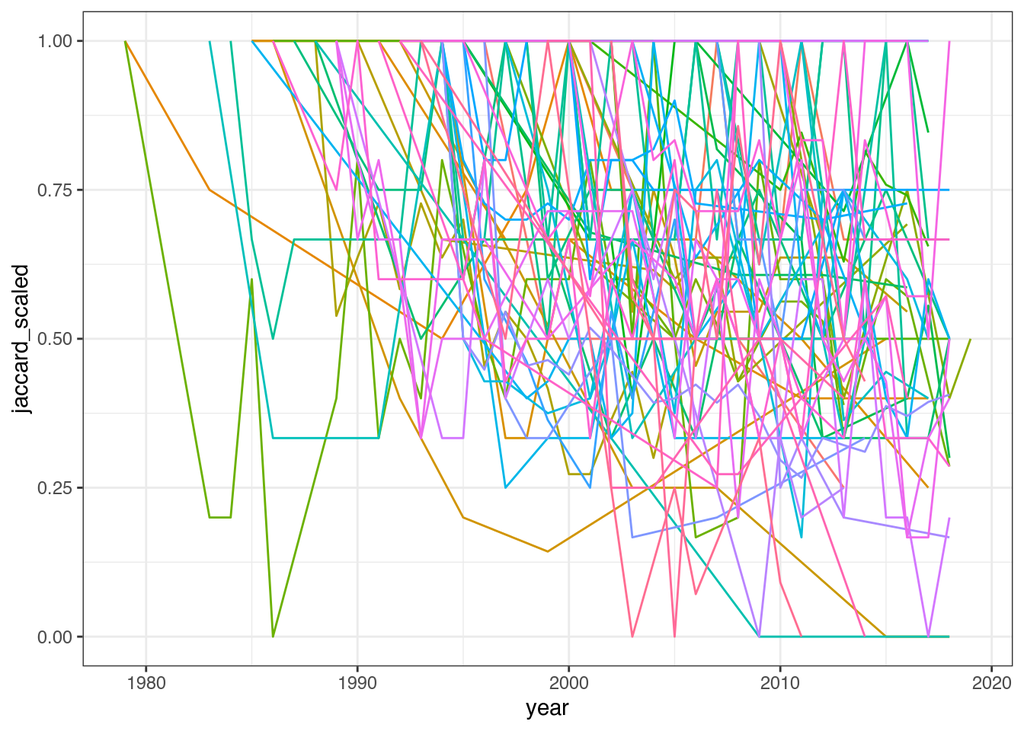

```r
analysis_dataset %>%
  filter(siteid %in% sample(unique(siteid))[1:60]) %>%
  ggplot(aes(y = jaccard_scaled, x = year, color = siteid)) +
  geom_line() +
  theme(legend.position = "none")
```

```r
# https://stats.stackexchange.com/q/423274
ti <- glmmTMB(jaccard_scaled ~ year * ecoregion +
  (1 + year | main_bas/siteid),
  family = list(family = "beta", link = "logit"),
  data = na.omit(analysis_dataset[, c("siteid", "jaccard_scaled", "year",
      "species_nb", "ecoregion", "main_bas")]))
```

```r
plot(resid(ti) ~ fitted(ti))
```

[output not shown]

```r
ti1 <- update(ti, dispformula = ~ species_nb)
```

```r
plot(resid(ti1) ~ fitted(ti1))
```

[output not shown]

### Test

```r
tar_load(fr)
skimr::skim(fr)
```

Data summary

| Name | fr |
| --- | --- |
| Number of rows | 11324 |
| Number of columns | 40 |
| _______________________ |  |
| Column type frequency: |  |
| character | 2 |
| factor | 1 |
| numeric | 37 |
| ________________________ |  |
| Group variables | None |

**Variable type: character**

| skim_variable | n_missing | complete_rate | min | max | empty | n_unique | whitespace |
| --- | --- | --- | --- | --- | --- | --- | --- |
| siteid | 0 | 1 | 2 | 5 | 0 | 935 | 0 |
| ecoregion | 0 | 1 | 10 | 10 | 0 | 1 | 0 |

**Variable type: factor**

| skim_variable | n_missing | complete_rate | ordered | n_unique | top_counts |
| --- | --- | --- | --- | --- | --- |
| main_bas | 0 | 1 | FALSE | 73 | 208: 2252, 208: 1566, 208: 1463, 208: 1232 |

**Variable type: numeric**

| skim_variable | n_missing | complete_rate | mean | sd | p0 | p25 | p50 | p75 | p100 | hist |
| --- | --- | --- | --- | --- | --- | --- | --- | --- | --- | --- |
| year | 0 | 1 | 2004.66 | 7.44 | 1978.00 | 1999.00 | 2005.00 | 2011.00 | 2017.00 | ▁▁▇▇▆ |
| total_abundance | 0 | 1 | 569.09 | 647.13 | 0.31 | 188.00 | 375.00 | 725.25 | 9850.00 | ▇▁▁▁▁ |
| log_total_abundance | 0 | 1 | 5.83 | 1.16 | -1.17 | 5.24 | 5.93 | 6.59 | 9.20 | ▁▁▂▇▁ |
| species_nb | 0 | 1 | 9.18 | 5.36 | 1.00 | 5.00 | 9.00 | 13.00 | 27.00 | ▇▇▆▂▁ |
| log_species_nb | 0 | 1 | 1.96 | 0.82 | 0.00 | 1.61 | 2.20 | 2.56 | 3.30 | ▂▂▅▇▅ |
| chao_richness | 0 | 1 | 7.74 | 4.82 | 1.00 | 3.93 | 7.30 | 10.97 | 43.41 | ▇▃▁▁▁ |
| chao_shannon | 0 | 1 | 4.07 | 2.36 | 0.00 | 2.41 | 3.92 | 5.64 | 14.26 | ▆▇▃▁▁ |
| chao_simpson | 0 | 1 | 3.14 | 1.80 | 0.00 | 1.90 | 3.01 | 4.27 | 11.46 | ▆▇▃▁▁ |
| chao_evenness | 0 | 1 | 2.08 | 1.24 | 0.00 | 1.72 | 2.17 | 2.54 | 38.25 | ▇▁▁▁▁ |
| jaccard | 0 | 1 | 0.67 | 0.25 | 0.00 | 0.50 | 0.67 | 0.86 | 1.00 | ▁▂▇▇▇ |
| horn | 0 | 1 | 0.77 | 0.21 | 0.00 | 0.67 | 0.80 | 0.92 | 1.00 | ▁▁▂▆▇ |
| chao | 0 | 1 | 0.94 | 0.21 | 0.00 | 1.00 | 1.00 | 1.00 | 1.00 | ▁▁▁▁▇ |
| hillebrand | 0 | 1 | 0.63 | 0.31 | 0.00 | 0.38 | 0.69 | 0.93 | 1.00 | ▂▃▃▃▇ |
| total | 0 | 1 | 0.23 | 0.17 | 0.00 | 0.10 | 0.23 | 0.33 | 1.00 | ▇▇▂▁▁ |
| appearance | 0 | 1 | 0.12 | 0.13 | 0.00 | 0.00 | 0.10 | 0.19 | 0.92 | ▇▂▁▁▁ |
| disappearance | 0 | 1 | 0.10 | 0.12 | 0.00 | 0.00 | 0.08 | 0.15 | 0.85 | ▇▂▁▁▁ |
| evenness | 0 | 1 | 0.59 | 0.24 | 0.00 | 0.52 | 0.66 | 0.75 | 1.00 | ▂▁▃▇▂ |
| shannon | 0 | 1 | 1.28 | 0.63 | 0.00 | 0.91 | 1.40 | 1.76 | 2.63 | ▃▃▇▇▂ |
| simpson | 0 | 1 | 0.58 | 0.26 | 0.00 | 0.48 | 0.68 | 0.77 | 0.91 | ▃▁▃▇▇ |
| jaccard_dis | 0 | 1 | 0.33 | 0.25 | 0.00 | 0.14 | 0.33 | 0.50 | 1.00 | ▇▇▆▂▁ |
| nestedness | 0 | 1 | 0.13 | 0.16 | 0.00 | 0.00 | 0.08 | 0.20 | 0.96 | ▇▂▁▁▁ |
| turnover | 0 | 1 | 0.20 | 0.24 | 0.00 | 0.00 | 0.15 | 0.33 | 1.00 | ▇▃▂▁▁ |
| dist_up_km | 0 | 1 | 91.50 | 137.90 | 3.40 | 18.70 | 35.80 | 92.60 | 876.30 | ▇▁▁▁▁ |
| ord_stra | 0 | 1 | 2.96 | 1.50 | 1.00 | 2.00 | 3.00 | 4.00 | 7.00 | ▇▅▃▂▁ |
| ele_mt_cav | 0 | 1 | 317.22 | 360.64 | 0.00 | 100.00 | 190.00 | 366.00 | 2158.00 | ▇▁▁▁▁ |
| tmp_dc_cyr | 0 | 1 | 105.55 | 17.12 | 23.00 | 97.00 | 107.00 | 115.00 | 147.00 | ▁▁▃▇▂ |
| dis_m3_pyr | 0 | 1 | 56.25 | 191.20 | 0.10 | 1.14 | 3.23 | 17.59 | 1725.47 | ▇▁▁▁▁ |
| pac_pc_cse | 0 | 1 | 18.39 | 35.72 | 0.00 | 0.00 | 0.00 | 8.00 | 100.00 | ▇▁▁▁▂ |
| urb_pc_cse | 0 | 1 | 7.77 | 20.40 | 0.00 | 0.00 | 0.00 | 0.00 | 100.00 | ▇▁▁▁▁ |
| hft_ix_c09 | 0 | 1 | 182.37 | 94.40 | 14.00 | 110.00 | 170.00 | 239.00 | 434.00 | ▅▇▆▃▂ |
| jaccard_scaled | 0 | 1 | 0.67 | 0.25 | 0.00 | 0.50 | 0.67 | 0.86 | 1.00 | ▁▂▇▇▇ |
| scaled_dist_up_km | 0 | 1 | 0.00 | 1.00 | -0.64 | -0.53 | -0.40 | 0.01 | 5.69 | ▇▁▁▁▁ |
| log_dist_up_km | 0 | 1 | 3.77 | 1.17 | 1.22 | 2.93 | 3.58 | 4.53 | 6.78 | ▂▇▇▃▂ |
| scaled_tmp_dc_cyr | 0 | 1 | 0.00 | 1.00 | -4.82 | -0.50 | 0.08 | 0.55 | 2.42 | ▁▁▃▇▂ |
| tmp_c_cyr | 0 | 1 | 10.56 | 1.71 | 2.30 | 9.70 | 10.70 | 11.50 | 14.70 | ▁▁▃▇▂ |
| scaled_tmp_c_cyr | 0 | 1 | 0.00 | 1.00 | -4.82 | -0.50 | 0.08 | 0.55 | 2.42 | ▁▁▃▇▂ |
| year_nb | 0 | 1 | 9.92 | 7.51 | 0.00 | 4.00 | 9.00 | 15.00 | 38.00 | ▇▆▃▁▁ |

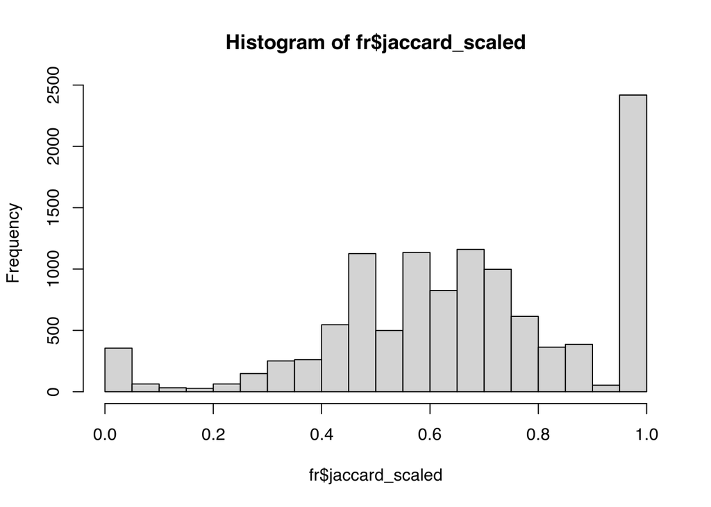

```r
hist(fr$jaccard_scaled)
```

```r
tabyl_df(fr, "main_bas")
```

```
#>    main_bas     n percent
#>  2080021030  2252   19.9%
#>  2080022150  1566   13.8%
#>  2080020590  1463   12.9%
#>  2080016510  1232   10.9%
#>  2080023010  1030    9.1%
#>  2080020620   511    4.5%
#>  2080020330   407    3.6%
#>  2080022970   352    3.1%
#>  2080021110   197    1.7%
#>  2080020730   148    1.3%
#>  2080016750   105    0.9%
#>  2080022030   103    0.9%
#>  2080022080    85    0.8%
#>  2080022770    85    0.8%
```

[output cut: 295 more lines]

- Relationships between jaccard and year number are highly non linear:
  - it might be more appropriate to model them with `log(year_nb)` to model linearly a negative exponential relationship. However it should not catch recovery from disturbance

[output not shown]

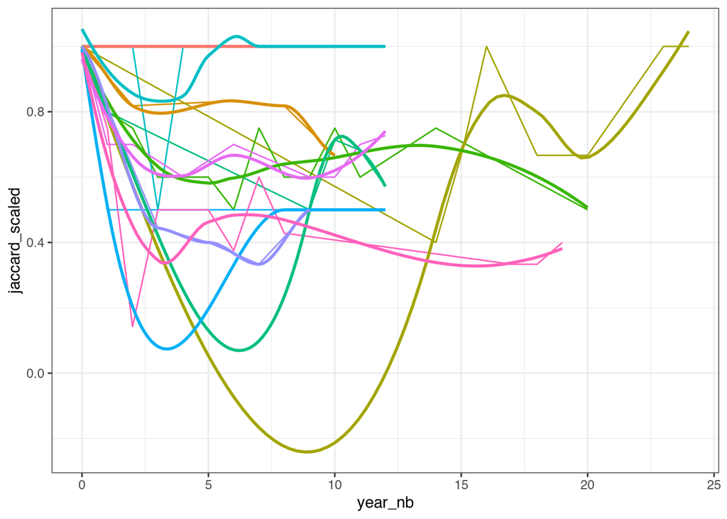

```r
fr %>%
  filter(siteid %in% sample(unique(siteid))[1:10]) %>%
  ggplot(aes(y = jaccard_scaled, x = year_nb, color = siteid)) +
  geom_line() +
  theme(legend.position = "none") +
  geom_smooth(se = FALSE)
```

- It is not pretty but seems not too bad

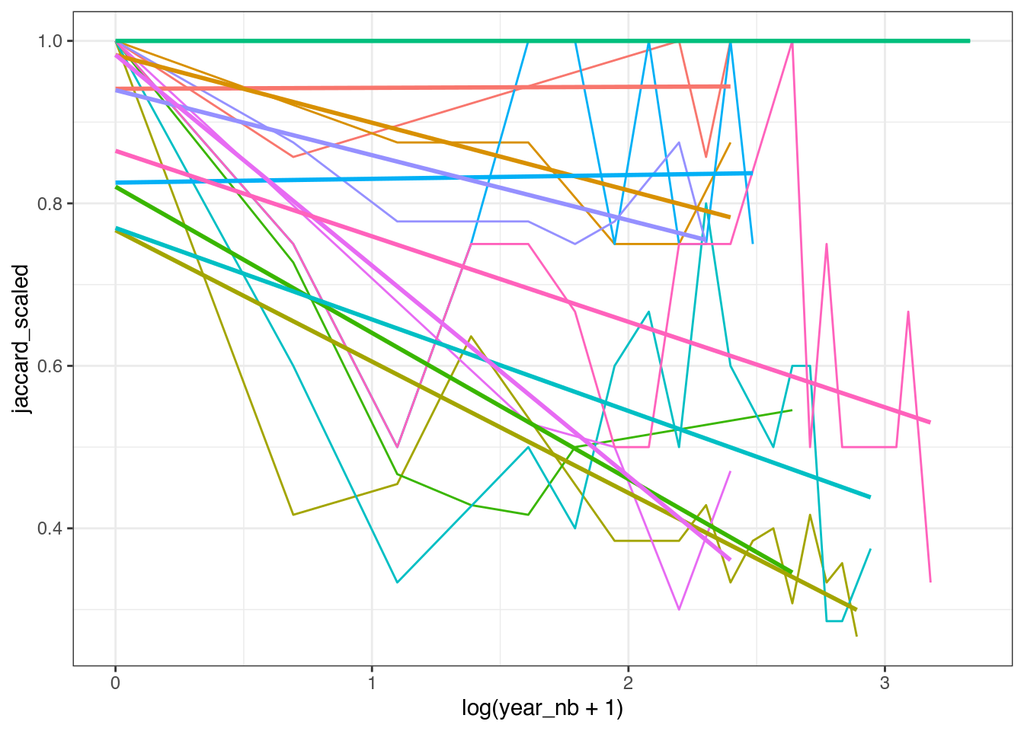

```r
sample_fr <- fr %>%
  filter(siteid %in% sample(unique(siteid))[1:10])
sample_fr %>%
  ggplot(aes(y = jaccard_scaled, x = log(year_nb + 1), color = siteid)) +
  geom_line() +
  theme(legend.position = "none") +
  geom_smooth(
    formula = y ~ x,
    method = "lm",
    se = FALSE
    )
```

- There are a clear relationship between stralher order and jaccard:
  - Higher turnover through time in higher stralher order, it is expected because there are more connected, larger, far from the source, and so a higher dispersion rate.

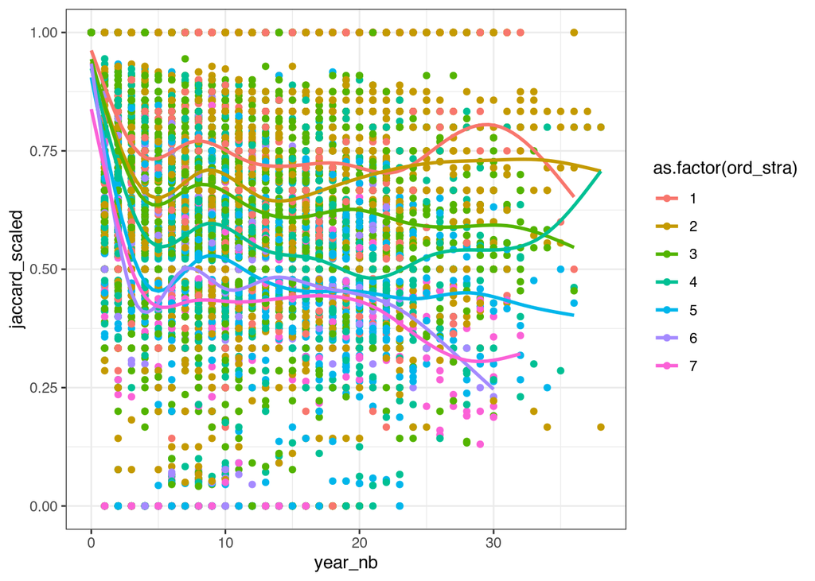

```r
fr %>%
  ggplot(aes(y = jaccard_scaled, x = year_nb, color = as.factor(ord_stra))) +
  geom_point() +
  geom_smooth(se = FALSE)
```

- Logging year number improved the linear shape of the relationship but that is far from being perfect

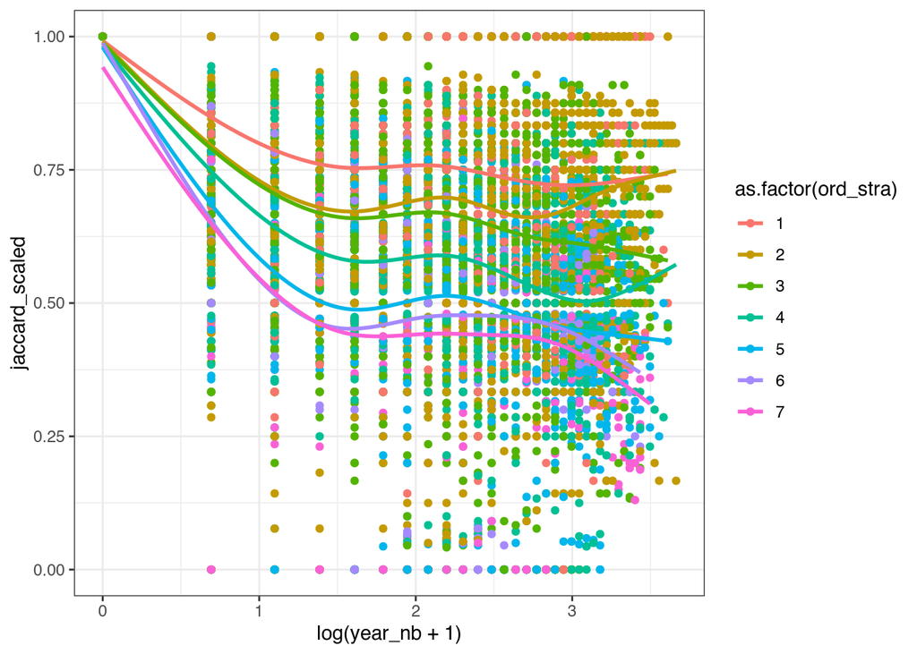

```r
fr %>%
  ggplot(aes(y = jaccard_scaled, x = log(year_nb + 1), color = as.factor(ord_stra))) +
  geom_point() +
  geom_smooth(se = FALSE)
```

- Logging both response and predictor do not improve stuff:

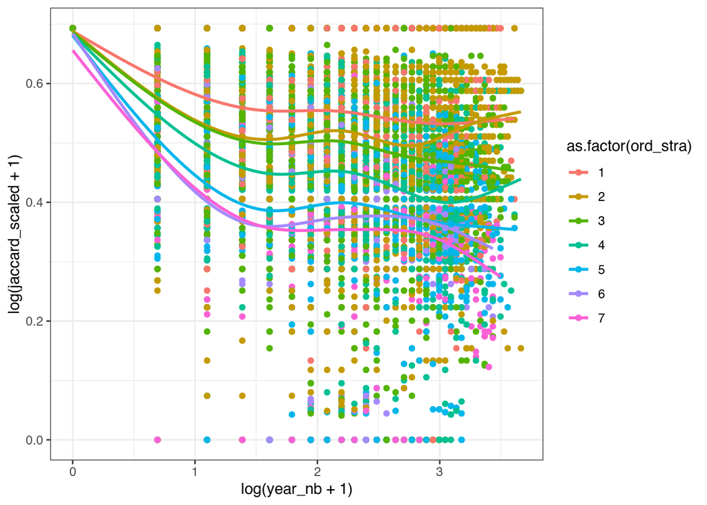

```r
fr %>%
  ggplot(aes(y = log(jaccard_scaled + 1), x = log(year_nb + 1), color = as.factor(ord_stra))) +
  geom_point() +
  geom_smooth(se = FALSE)
```

- Temperature:

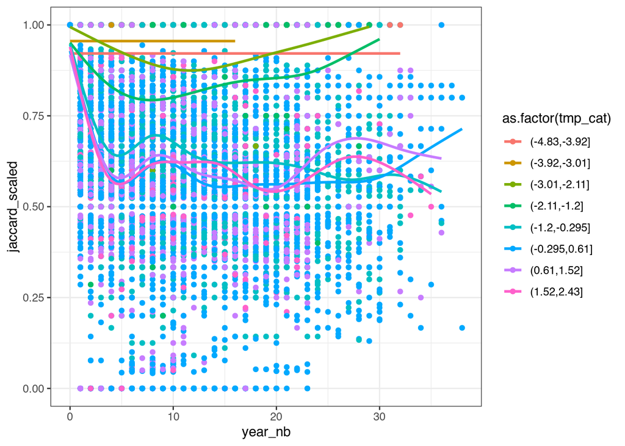

```r
fr %>%
  mutate(tmp_cat = cut(scaled_tmp_c_cyr, breaks = 8)) %>%
  ggplot(aes(y = jaccard_scaled, x = year_nb, color = as.factor(tmp_cat))) +
  geom_point() +
  geom_smooth(se = FALSE)
```

- Are there two synergistic effects here, like dissimilarity increase more far the source (dispersal effect) but at the same dissimilarity increase more in warm water, both variables might be collinear, right?

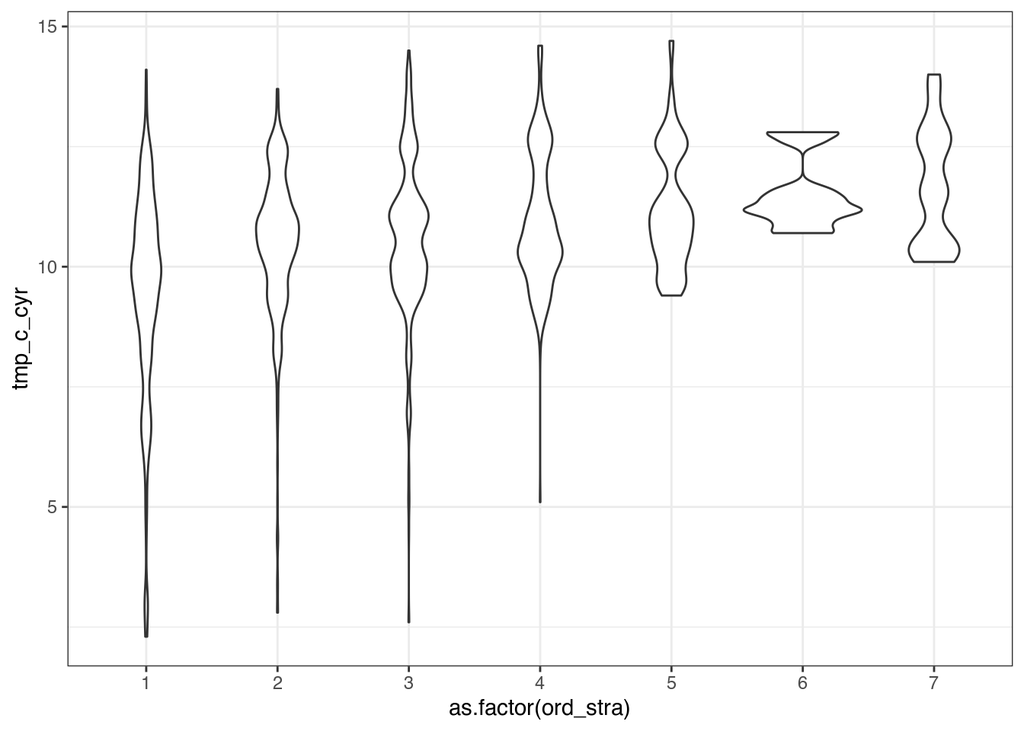

```r
fr %>%
  ggplot(aes(y = tmp_c_cyr, x = as.factor(ord_stra))) +
  geom_violin()
```

- Collinearity is weak between temperature and strahler, so it is good:

```r
cor(fr$tmp_c_cyr, fr$ord_stra, method = "spearman")
```

```
#> [1] 0.2882401
```

```r
car::vif(lm(jaccard_scaled ~ scaled_tmp_c_cyr + scaled_dist_up_km, fr))
```

```
#>  scaled_tmp_c_cyr scaled_dist_up_km
#>          1.060631          1.060631
```

```r
knitr::opts_chunk$set(eval = FALSE)
```

```r
tar_load(beta_jaccard_tmb)
confint(beta_jaccard_tmb)
analysis_dataset
res_b_j <- simulateResiduals(beta_jaccard_tmb)

summary(beta_jaccard_tmb)
library(emmeans)
x <- coef(beta_jaccard_tmb)$cond
str(x)
confint(beta_jaccard_tmb, "year_nb", component = "cond")
y <- x[["siteid:main_bas"]]
emmeans(beta_jaccard_tmb, "year_nb", type = "response")
r2(beta_jaccard_tmb)
```

```r
pred <- ggemmeans(beta_jaccard_tmb,
  terms = c("year_nb", "scaled_dist_up_km [quart2]"),
  type = "re.zi")
plot(pred)
```

```r
tar_load(c(rigal_trends, var_temporal_trends))
names(rigal_trends) <- var_temporal_trends

hist(coef(beta_jaccard_tmb)$cond[["siteid:main_bas"]]$year_nb)
```

- Site:

```r
tar_load(gaussian_jaccard_tmb)
par(mfrow = c(1, 2))
hist(coef(gaussian_jaccard_tmb)$cond[["siteid:main_bas"]]$year_nb)
hist(rigal_trends[["jaccard"]]$linear_slope)
```

```r
plot(
  coef(gaussian_jaccard_tmb)$cond[["siteid:main_bas"]]$year_nb,
  coef(beta_jaccard_tmb)$cond[["siteid:main_bas"]]$year_nb,
  xlim= c(-.5,.2), ylim = c(-.5,.2)
)
abline(0,1)
```

- Basin:

```r
x <- coef(gaussian_jaccard_tmb)$cond[["siteid:main_bas"]] %>%
  rownames_to_column(var = "siteid_main_bas") %>%
  separate(
    col = "siteid_main_bas",
    into = c("siteid", "main_bas"),
    sep = ":")

hist(coef(gaussian_jaccard_tmb)$cond[["main_bas"]]$year_nb)
```

```r
tar_load(filtered_dataset)
loc <- filtered_dataset$location %>%
  left_join(filtered_dataset$site_quali, by = "siteid") %>%
  st_as_sf(coords = c("longitude", "latitude"),
  crs = 4326)
```

```r
loc_slp <- loc %>%
  left_join(select(x, -main_bas), by = c("siteid"))

world <- ne_countries(scale = "medium", returnclass = "sf")
bb <- st_bbox(loc)
ggplot(data = world) +
    geom_sf() +
    geom_sf(data = loc_slp, aes(color = year_nb), shape = 23) +
    scale_color_viridis() +
    theme(legend.position = "bottom") +
    labs(title = paste0("Number of sites: ", nrow(loc)))
length(unique(na.omit(analysis_dataset)$siteid))
```

```r
ti <- glmmTMB(
  jaccard_scaled ~ 0 + year_nb * scaled_dist_up_km +
  (0 + year_nb | main_bas/siteid),
offset = rep(1.0, nrow(fr)),
  family = beta_family(link = "logit"),
  data = fr)
diagnose(ti)
```

```r
res_sim <- simulateResiduals(ti)
plot(res_sim)
plot(residuals(ti) ~ fitted(ti))
plot(fr$jaccard_scaled ~ fitted(ti))
```

```r
confint(ti)
```

```r
ti1 <- update(ti, dispformula = ~ year_nb)
diagnose(ti1)
```

```r
res_sim1 <- simulateResiduals(ti1)
plot(res_sim1)

confint(ti1)
```

```r
ti2 <- update(ti1, dispformula = ~ year_nb + scaled_dist_up_km)
diagnose(ti2)
```

```r
res_sim2 <- simulateResiduals(ti2)
plot(res_sim2)

confint(ti2)
```

```r
ti3 <- update(ti2, formula = jaccard_scaled ~
  0 + year_nb/scaled_dist_up_km +
  (0 + year_nb | main_bas/siteid))
diagnose(ti3)
```

```r
res_sim3 <- simulateResiduals(ti3)
plot(res_sim3)

confint(ti3)
```

- Normal distribution:

```r
?family_glmmTMB
tn <- glmmTMB(jaccard_scaled ~
  0 + year_nb * scaled_dist_up_km +
  (0 + year_nb | main_bas/siteid) +
  (0 + scaled_dist_up_km | main_bas),
offset = rep(1.0, nrow(fr)),
  family = gaussian(link = "identity"),
  data = fr)
diagnose(tn)
summary(tn)
plot(resid(tn) ~ fitted(tn))
plot(fr$jaccard_scaled ~ fitted(tn))
abline(c(0,1))
```

```r
confint(tn)
```

### Species richness

```r
sp_tmb <- glmmTMB(species_nb ~
  year_nb * scaled_dist_up_km +
  (1 + year_nb | main_bas / siteid) +
  (1 + scaled_dist_up_km | main_bas),
  offset = NULL,
  dispformula = ~1,
  family = nbinom2(link = "log"),
  data = fr)
diagnose(sp_tmb)
```

```r
res_sp <- simulateResiduals(sp_tmb)
plot(res_sp)
testDispersion(res_sp)
testZeroInflation(res_sp)
```

```r
sp_tmb1 <- update(sp_tmb,
  formula = species_nb ~
  year_nb +
  (1 + year_nb | main_bas / siteid) +
  (1 + scaled_dist_up_km | main_bas),
  ziformula = ~ main_bas + siteid)
diagnose(sp_tmb1)
```

```r
res_sp1 <- simulateResiduals(sp_tmb1)
plot(res_sp1)
testDisp1ersion(res_sp1)
testZeroInflation(res_sp1)
```

## INLA

- General model of Van Klink:

```r
inla(x ~ Year: Realm: U + Realm + U +
  f(Period, model = 'iid')+
  # random intercept season
  f(Plot_ID, model = 'iid')+
  # random intercept site
  f(StudyArea_ID, model='iid')+
  # random intercept study area
  f(Datasource_ID, model='iid')+
  # random intercept study
  f(Plot_ID_slope, iYear, model='iid')+
  # random slope site
  f(StudyArea_ID_slope, iYear, model='iid')+
  # random slope study area
  f(Datasource_ID_slope, Year, model='iid') +
  # random slope study
  f(Year,model='ar1', replicate=as.numeric(Plot_ID)), # AR1 term
family="gaussian"
# normal distribution
)
```

# Test

## Test Illinois

```r
site_il <- filtered_dataset$location %>%
  filter(region == "ILLINOIS")
fish_il <- filtered_dataset$measurement %>%
  filter(siteid %in% site_il$siteid)
il_dataset <- fish_il %>%
  left_join(site_il, by = "siteid")
```

```r
m0 <- inla(abundance ~ 1, data = il_dataset)
m0_1 <- inla(abundance ~ 1, family = "poisson", data = il_dataset)
m1 <- inla(abundance ~ year, family = "poisson", data = il_dataset)
m1_1 <- inla(abundance ~ as.factor(year), family = "poisson", data = il_dataset)
```

```r
p <- map(unique(unique(il_dataset$siteid)),
  ~plot_temporal_population(com = filter(il_dataset, siteid == .x))
)
plot_grid(plotlist = p[1:4])
plot_grid(plotlist = p[5:8])
plot_grid(plotlist = p[9:12])
```

```r
il_abun_rich <- filtered_dataset$abun_rich_op %>%
  filter(siteid %in% site_il$siteid)
```

```r
a1 <- inla(total_abundance ~ year,
  family = "poisson",
  control.family=list(link='log'),
  data = il_abun_rich)
```

```r
get_data_pred_inla <- function(dataset = NULL, predictor = NULL, y = NULL) {

  fitted <- dataset[, c(y, predictor)]
  fitted[[y]] <- NA
  l <- map(predictor, ~seq(min(dataset[[.x]]), max(dataset[[.x]]), len = 100))
  names(l) <- predictor
  l[[y]] <- NA
  newdata <- expand.grid(l)
  dat_pred <- bind_rows(dataset, fitted, newdata)
  list(
    dat_pred = dat_pred,
    newdata = newdata,
    fitted = fitted,
    rows = (nrow(dataset) + nrow(fitted)+1):nrow(dat_pred)
  )
}
test <- get_data_pred_inla(dataset = il_abun_rich, predictor = "year", y =
  "total_abundance")
```

```r
a1 <- inla(total_abundance ~ year,
  family = "poisson",
  control.family = list(link='log'),
  control.predictor = list(link=1, compute=TRUE),
  data = test$dat_pred)
summary(a1)
```

```r
newdata <- cbind(
  test$newdata,
  a1$summary.fitted.values[test$rows,])
newdata <- rename(newdata, "lower" = "0.025quant", "upper"="0.975quant")

ggplot(newdata, aes(y = mean, x = year)) +
        geom_blank() +
        geom_point(data = il_abun_rich, aes(y = total_abundance, x = year)) +
        geom_ribbon(aes(ymin = lower-100, ymax = upper+100), fill = 'blue', alpha = 0.2) +
        geom_line()
```

```r
a2 <- inla(total_abundance ~ year,
  family = "nbinomial",
  control.family = list(link='log'),
  control.predictor = list(link=1, compute=TRUE),
  data = test$dat_pred)
```

```r
newdata <- cbind(
  test$newdata,
  a2$summary.fitted.values[test$rows,])
newdata <- rename(newdata, "lower" = "0.025quant", "upper"="0.975quant")

ggplot(newdata, aes(y = mean, x = year)) +
        geom_blank() +
        geom_point(data = il_abun_rich, aes(y = total_abundance, x = year)) +
        geom_ribbon(aes(ymin = lower, ymax = upper), fill = 'blue', alpha = 0.2) +
        geom_line()
```

```r
a3 <- inla(total_abundance ~ year + f(siteid, model = "iid"),
  family = "nbinomial",
  control.family = list(link = "log"),
  control.predictor = list(link = 1, compute = TRUE),
  control.compute = list(cpo = TRUE, dic = TRUE, config = TRUE),
  data = test$dat_pred)
plot(a3)
```

- inlatools checks:

```r
check <- distribution_check(a3, nsim = 100)
plot(check)
disp <- dispersion_check(a3)
plot(disp)
```

```r
post <- inla.posterior.sample(n = 100, result = a3)

relevant <- grep("^Predictor:", rownames(post[[1]]$latent))
eta <- map_dfc(post, "latent")[relevant, , drop = FALSE]

relevant <- grep(
  "size for the nbinomial observations",
  names(post[[1]]$hyperpar)
)
size <- inla.hyperpar.sample(n = 100, result = a3)[, relevant] #nolint
simulated_values <- as_tibble(mutate_all(
  exp(eta),
  function(mu) {
    rnbinom(n = length(mu), mu = mu, size = size)
  }
  ))

library(DHARMa)
relevant_data <- !is.na(test$dat_pred$total_abundance)
sim <- createDHARMa(
  simulatedResponse = as.matrix(simulated_values)[relevant_data,],
  observedResponse = test$dat_pred$total_abundance[relevant_data],
  fittedPredictedResponse = a3$summary.fitted.values$mean[relevant_data],
  integerResponse = T)
plot(sim, asFactor = T)
```

```r
a3_spamm <- fitme(
  total_abundance ~ year + (1|siteid),
  data = test$dat_pred,
  family = "negbin")
#1/1.457
```

```r
simulationOutput <- simulateResiduals(fittedModel = a3_spamm)
plot(simulationOutput, asFactor = T)
testZeroInflation(simulationOutput)
testDispersion(simulationOutput)
```

```r
m2 <- inla(abundance ~ year:species,
  family = "poisson",
  control.family=list(link='log'),
  data = il_dataset)
summary(m2)
time_effect <- round(m2$summary.fixed, 4) %>%
  as_tibble(., rownames = "effect")
exp(time_effect$mean)
```

```r
tar_load(c(analysis_dataset))
```

```r
# To continue
il_dataset
model_com <- map(
  c("total_abundance_int",
    "species_nb",
    "chao_richness",
    "chao_shannon",
    "chao_simpson"),
  ~spaMM::fitme(
    as.formula(paste0(.x, "~
        year +
        unitabundance +
        (1 | ecoregion / siteid) +
        (year | first_year)")),
  data = analysis_dataset,
  family = "negbin"
)


)
usethis::use_data(model_com)
library(datasets)

mtcars
y <- "test"
library(rlang)

rm("mtcars")
load(here("data", paste0(y, ".rda")))
usethis::use_data(bquote(y))
usethis::use_data(UQ(y))
unquote(y)
!!sym(y)
UQ(enquo(y))

test
```

```r
analysis_dataset %>%
  ggplot(aes(x = year, y = log(total_abundance_int))) +
  geom_point() +
  geom_smooth(method = "auto")
```

```r
analysis_dataset %>%
  ggplot(aes(x = total_abundance_int)) +
  geom_histogram()
```

```r
inla_b0 <- inla(
  total_abundance_int ~
    year +
    unitabundance +
    f(siteid, model = "iid") +
    f(span, year, model = "iid"),
  family = "nbinomial",
  control.family = list(link = "log"),
  control.predictor = list(link = 1, compute = TRUE),
  control.compute = list(cpo = TRUE, dic = TRUE, config = TRUE),
  data = analysis_dataset
  )
```

```r
check <- distribution_check(inla_b0, nsim = 100)
plot(check)
disp <- dispersion_check(inla_b0)
plot(disp)
```

```r
inla_rich <- inla(
  species_nb ~
    year +
    f(siteid, model = "iid") +
    f(span, year, model = "iid"),
  family = "nbinomial",
  control.family = list(link = "log"),
  control.predictor = list(link = 1, compute = TRUE),
  control.compute = list(
    cpo = TRUE,
    dic = TRUE,
    config = TRUE,
    return.marginals.predictor = TRUE),
  data = analysis_dataset
  )
```

```r
get_simulated_values_negbinom <- function(inla_obj = NULL, nsim = 100) {

  post <- inla.posterior.sample(n = nsim, result = inla_obj)


  relevant <- grep("^Predictor:", rownames(post[[1]]$latent))
  eta <- map_dfc(post, "latent")[relevant, , drop = FALSE]

  relevant <- grep(
    "size for the nbinomial observations",
    names(post[[1]]$hyperpar)
  )
  size <- inla.hyperpar.sample(n = 100, result = inla_obj)[, relevant] #nolint
  simulated_values <- as_tibble(mutate_all(
      exp(eta),
      function(mu) {
        rnbinom(n = length(mu), mu = mu, size = size)
      }
      ))

  return(simulated_values)
}
get_dharma_inla_negbinom <- function(inla_obj = NULL, nsim = 100, raw_data =
  NULL, resp_var = NULL) {

  sim <- get_simulated_values_negbinom(inla_obj = inla_rich, nsim = nsim)

  relevant_data <- !is.na(raw_data[[resp_var]])
  output <- createDHARMa(
    simulatedResponse = as.matrix(sim)[relevant_data,],
    observedResponse = raw_data[[resp_var]][relevant_data],
    fittedPredictedResponse =
      inla_obj$summary.fitted.values$mean[relevant_data],
    integerResponse = T)

  return(output)

}

debugonce(get_dharma_inla_negbinom)
get_dharma_inla_negbinom(inla_obj = inla_rich, nsim = 100, raw_data =
  analysis_dataset, resp_var = "species_nb")
```

```r
plot(inla_rich, plot.prior = TRUE)
```

```r
check <- distribution_check(inla_rich, nsim = 100)
plot(check)
disp <- dispersion_check(inla_rich)
plot(disp)
```

```r
tar_load(c(rigal_trends, var_rigal))
names(rigal_trends) <- var_rigal
summary(rigal_trends$log_total_abundance$first_order_coefficient)
```

```r
b0 <- spaMM::fitme(
  total_abundance_int ~
    year +
    unitabundance +
    (1 | ecoregion / siteid) +
    (year | first_year),
  data = analysis_dataset,
  family = "negbin"
)

b0 <- spaMM::fitme(
  total_abundance_int ~
    year +
    unitabundance +
    (1 | ecoregion / siteid) +
    (year | first_year),
  data = analysis_dataset,
  family = "negbin"
)
```

```r
simulationOutput <- simulateResiduals(fittedModel = b0)
plot(simulationOutput, asFactor = T)
testZeroInflation(simulationOutput)
testDispersion(simulationOutput)

par(mfrow = c(1,2))
plotResiduals(simulationOutput, analysis_dataset$year)
plotResiduals(simulationOutput, analysis_dataset$unitabundance)
```

- Zero inflated:

```r
tb0 <- fitme(
 total_abundance_int ~ year + unitabundance + (1 | ecoregion / siteid),
  data = analysis_dataset,
  family = Tnegbin(trunc = 0L, link = "log")
)
```

## Reproducibility

**Reproducibility receipt**

```r
## datetime
Sys.time()

## repository
if(requireNamespace('git2r', quietly = TRUE)) {
  git2r::repository()
} else {
  c(
    system2("git", args = c("log", "--name-status", "-1"), stdout = TRUE),
    system2("git", args = c("remote", "-v"), stdout = TRUE)
  )
}

## session info
sessionInfo()
```